# PAC4 - Anàlisi de variànçia i repàs del curs

# 5 Comparacions múltiples

**Independentment del resultat obtingut en l’apartat anterior, vam realitzar un test de comparació múltiple entre els grups. Aquest test s’aplica quan el test ANOVA retorna rebutjar la hipòtesi nul·la d’igualtat de mitjanes. Per tant, procedirem com si el test ANOVA hagués donat com a resultat el rebuig de la hipòtesi nul·la.**

## 5.1 Sense correcció

**Calcular les comparacions entre grups sense cap tipus de correcció. Podeu utilitzar la funció pairwise.t.test.**

Apliqueu la prova amb dues cues. Identificar els parells que són significativament diferents amb un valor alfa=0.05.

```r
pw.noadjust <- pairwise.t.test(mydata$AE, mydata$Tipo, p.adjust.method ="none", alternative="two.side")
pw.noadjust
```

```
##
##  Pairwise comparisons using t tests with pooled SD
##
## data:  mydata$AE and mydata$Tipo
##
##    FI      FL      FM      FP      NF
## FL 0.14264 -       -       -       -
## FM 0.27780 0.69003 -       -       -
## FP 0.00228 0.11110 0.04451 -       -
## NF 2.5e-13 6.9e-10 6.2e-11 8.2e-07 -
## NI 0.00051 0.04400 0.01484 0.67704 3.6e-06
##
## P value adjustment method: none
```

## 5.2 Correcció de Bonferroni

**Aplicar la correcció de Bonferroni en la comparació múltiple. Interpretar el resultat i contrastar el resultat amb l’obtingut sense correcció.**

L’ajust de Bonferroni, que consisteix en dividir l’error de tipus I (α) pel nombre de comparacions. Així $\alpha^* = \frac{\alpha}{ k \choose n}$

Cada comparació entre un parell de mostres es fa amb el valor $α^∗$. El test de Bonferroni és excessivament conservador i pot tenir un elevat error de tipus II, és a dir, no detectar diferències quan aquestes hi són.

```r
pw.bonf <- pairwise.t.test(mydata$AE, mydata$Tipo, p.adjust.method ="bonferroni", alternative="two.side")
pw.bonf
```

```
##
##  Pairwise comparisons using t tests with pooled SD
##
## data:  mydata$AE and mydata$Tipo
##
##    FI      FL      FM      FP      NF
## FL 1.0000  -       -       -       -
## FM 1.0000  1.0000  -       -       -
## FP 0.0342  1.0000  0.6676  -       -
## NF 3.7e-12 1.0e-08 9.3e-10 1.2e-05 -
## NI 0.0077  0.6600  0.2226  1.0000  5.5e-05
##
## P value adjustment method: bonferroni
```

## 5.3 Prova de Scheffé

**La prova de Scheffé és una de les més usades quan es compleixen condicions d’igualtat de variància. Segons López, està basada en la distribució F. Permet la comparació binària entre parells de mitges i també la comparació múltiple. En les comparacions de parells és conservadora. Es pot aplicar amb mostres de mida desigual i és força robusta davant l’incompliment de la condició d’homoscedasticitat.** **Apliqueu la prova de Scheffé i interpretar el resultat.**

En general, el mètode de Scheffe explica la taxa d’error de la família mitjançant la ponderació de l’estadística de prova (CC) mitjançant l’error quadrat mitjà (MSEMSE), les mostres entre DF (k-1,k-1) i les mides de grup (si són desiguals):

$C = \sqrt{(k - 1)~F~MSE~(\frac{1}{n_i} + \frac{1}{n_j})}$

```r
pw.scheffe <- ScheffeTest(x=anova_4, which="Tipo", conf.level = 0.95)
pw.scheffe
```

```
##
##   Posthoc multiple comparisons of means : Scheffe Test
##     95% family-wise confidence level
##
## $Tipo
##              diff      lwr.ci     upr.ci    pval
## FL-FI  0.31717895 -0.41054995  1.0449078 0.82268
## FM-FI  0.23127500 -0.48706345  0.9496134 0.94500
## FP-FI  0.66219000 -0.05614845  1.3805284 0.09157 .
## NF-FI  1.78410526  1.05637637  2.5118342 1.6e-10 ***
## NI-FI  0.74969048  0.03995519  1.4594258 0.03108 *
## FM-FL -0.08590395 -0.81363284  0.6418249 0.99947
## FP-FL  0.34501105 -0.38271784  1.0727399 0.76389
## NF-FL  1.46692632  0.72992662  2.2039260 2.7e-07 ***
## NI-FL  0.43251153 -0.28672653  1.1517496 0.53111
## FP-FM  0.43091500 -0.28742345  1.1492534 0.53392
## NF-FM  1.55283026  0.82510137  2.2805592 2.9e-08 ***
## NI-FM  0.51841548 -0.19131981  1.2281508 0.30238
## NF-FP  1.12191526  0.39418637  1.8496442 0.00016 ***
## NI-FP  0.08750048 -0.62223481  0.7972358 0.99935
## NI-NF -1.03441479 -1.75365285 -0.3151767 0.00057 ***
##
## ---
## Signif. codes:  0 '***' 0.001 '**' 0.01 '*' 0.05 '.' 0.1 ' ' 1
```

La taula dels resultats proporciona la comparació de les mitjanes, per a tota combinació possible de grups. La comparació es fa amnb el valor “Crític de F”, i els valors p es generen en funció d’això.

Hem de mirar si el p-value es inferior a 0.05 per indicar si la mitjana dels dos grups comparants és diferents, en aquest cas NF-FI, NF-FL, NI-FI, NF-FL, NF-FM, NF-FP i NI-NF té un valor p de inferiora 0.05, que diu que la mitjana dels grups són significativament diferents.

Veiem que exactament 6 contrastos són significatius mentre que 9 no ho són.

# 6 ANOVA multifactorial

**En una segona fase de la investigació es va avaluar l’efecte del sexe com a variable independent. Amb aquest objectiu, es va recol·lectar un segon conjunt de dades amb les variables independents sexe i nivell de fumador i amb la variable dependent capacitat pulmonar mida segons l’aire expulsat, igual que amb el primer conjunt de dades. Aquest conjunt de dades es troba en el fitxer Fumadores2.csv**

## 6.1 Estudiar els efectes principals i possibles interaccions

**Examinar les característiques del conjunt de dades i realitzar un estudi visual de les dades. A continuació, aplicar ANOVA. Seguir els passos que s’indiquen a continuació.**

### 6.1.1 Anàlisi visual

**Es realitzarà un primer estudi visual per determinar si només existeix efectes principals o hi ha efectes d’interacció entre sexe i tipus de fumador. Per a això, seguir els passos que s’indiquen a continuació:**

**1. Llegir el conjunt de dades**

```r
mydata2 <- read.csv2(file = "Fumadores2.csv", header = TRUE, sep = ",", quote = "\"", dec = ".", fill = TRUE, encoding="UTF-8")
names(mydata2)
```

```
## [1] "AE"   "Tipo" "Sex"
```

```r
# breu resumen dels atributs
head(mydata2, n=5)
```

| AE | Tipo | Sex |
| --- | --- | --- |
| 3.607107 | NF | M |
| 3.708264 | NF | M |
| 3.824298 | NF | M |
| 3.355295 | NF | M |
| 3.921486 | NF | M |

**2. Agrupar el conjunt de dades per tipus de fumador i sexe i calcular la mitjana d’AE en cada grup. Podeu fer servir les instruccions group_by i summarise de la llibreria dplyr per realitzar aquest procés. Mostra el conjunt de dades en forma de taula, on es mostri la mitjana de cada grup segons el sexe i tipus de fumador.**

```r
by_Tipo_vrs_Sex <- mydata2 %>%
  group_by(Tipo, Sex ) %>%
  summarise(mean = mean(AE), sd = sd(AE))

by_Tipo_vrs_Sex
```

| Tipo | Sex | mean | sd |
| --- | --- | --- | --- |
| FI | F | 2.153394 | 0.8045994 |
| FI | M | 2.486166 | 0.8875409 |
| FL | F | 2.743544 | 0.7966098 |
| FL | M | 3.037663 | 0.7124353 |
| FM | F | 2.282694 | 0.8058870 |
| FM | M | 2.574741 | 0.7630455 |
| FP | F | 3.301332 | 0.3866788 |
| FP | M | 3.406332 | 0.4123249 |
| NF | F | 3.641762 | 0.3967712 |
| NF | M | 3.748391 | 0.5643445 |
| NI | F | 3.163780 | 0.9818005 |
| NI | M | 3.292063 | 0.9255948 |

**3. Mostra en un plot d’AE per a cada tipus de fumador i sexe. Podeu inspirar-en els gràfics de López-Roldán i Fachelli (2015), pàg.38. Podeu realitzar aquest tipus de gràfic utilitzant la funció ggplot de la llibreria ggplot2.**

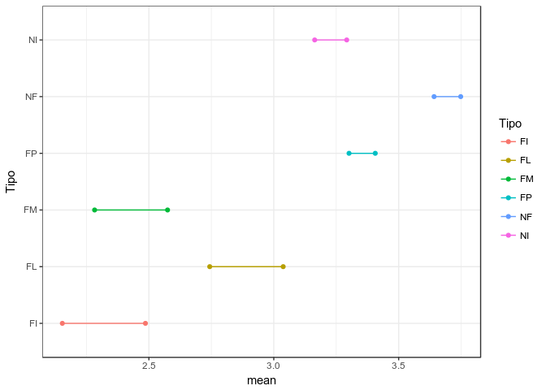

```r
ggplot(data = by_Tipo_vrs_Sex,
       aes(x = mean, y = Tipo, colour = Tipo, group = Tipo)
    ) +
    stat_summary(fun.y = mean, geom = "point") +
    stat_summary(fun.y = mean, geom = "line") +
    theme_bw()
```

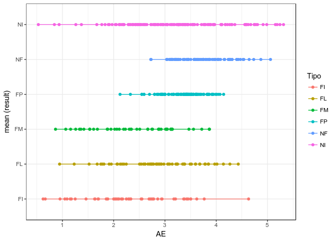

```r
ggplot(data = mydata2, aes(x = AE, y = Tipo, colour = Tipo, group = Tipo)) +
    stat_summary(fun.y = mean, geom = "point") + stat_summary(fun.y = mean,
    geom = "line") + labs(y = "mean (result)") + theme_bw()
```

**4. Interpretar el resultat sobre si hi ha només efectes principals o hi ha interacció. Si hi ha interacció, explicar com s’observa i quins efectes produeix aquesta interacció.**

Interpretem els resultats observant que hi ha relació directa entre el sexe dels fumadors que són dels tipus: FI, FN i FL i la capacitat pulmonar envers el sexe masculí.

Per contra els tipus de NI, NF i FP de fumadors no hi ha diferència significativa.

### 6.1.2 ANOVA multifactorial

**Calcular ANOVA multifactorial per avaluar si la variable dependent AE es pot explicar a partir de les variables independents sexe i tipus de fumador. Incloeu l’efecte de la interacció només si s’ha observat aquesta interacció en l’anàlisi visual de l’apartat anterior. Interpreteu el resultat.**

Utilitzarem l’anàlisi d’abans amb l’Anova amb 2 variables explicatives.

#### 6.1.2.1 Hipotesi nul·la

$H_0:\mu_0 = \mu_1$

#### 6.1.2.2 Hipotesi alternativa

$H_1:\mu_0 \neq \mu_1$

Fem servir la funció AOV per concloure si hi ha diferencies entre les mitjanes.

```r
anova_2_variables <- aov(AE ~ Tipo+Sex, mydata2)
summary(anova_2_variables)
```

```
##              Df Sum Sq Mean Sq F value  Pr(>F)
## Tipo          5 100.05  20.009  37.456 < 2e-16 ***
## Sex           1   3.92   3.922   7.343 0.00697 **
## Residuals   495 264.43   0.534
## ---
## Signif. codes:  0 '***' 0.001 '**' 0.01 '*' 0.05 '.' 0.1 ' ' 1
```

El resultat del p-value del Tipo és 1.392373310^{-32} i el del Sex és 0.0069676.

Els 2 resultat són menor que 0.05, per tant rebutjem la hipòtesis nul·la $H_o\;$, podem afirmar que les mitjanes son diferents.

# 7 Bibliografia

- https://rpubs.com/crazyhottommy/reorder-boxplot
- https://forcats.tidyverse.org/reference/fct_reorder.html
- https://rstudio-pubs-static.s3.amazonaws.com/326337_2155b78b37f74027869879598fb0d614.html#scheffes-test
- https://rpubs.com/Joaquin_AR/219148
- https://ca.wikibooks.org/wiki/Manual_de_R_(Estad%C3%ADstica)
- http://halweb.uc3m.es/esp/Personal/personas/amalonso/esp/p-valor.pdf
- https://es.wikipedia.org/wiki/Test_de_Shapiro–Wilk
- https://ca.wikipedia.org/wiki/Distribuci%C3%B3_t_de_Student
- https://rpubs.com/alvarohdez/101424